# College Football 2019

Andrew Lee

# Overview

College football is played by teams of student athletes consisting of North American colleges. The dataset used in this project contains records of 130 colleges in 2019 season. In this project, I tried to build a model which can predict the proportion of wins, based on different regressors.

Load packages:

```r
library(caret)
library(WVPlots)
library(faraway)
```

Load data:

```r
CFB.data = read.csv("CFB2019.csv")
rownames(CFB.data) = CFB.data$Team

# remove team names
CFB.data = CFB.data[,-1]
dim(CFB.data)
```

```
## [1] 130 145
```

The raw data has 130 observations and 145 columns.

# Data Cleaning

Before starting analysis, I did some data cleaning. Firstly, I removed all the ranking variables from independent variables, because the ranking variables are nothing else than sorted order of other variables. Also, changed type of the “Time” related variables. The unit of the variable is millisecond. So, I changed the string and treated as numeric as below.

```r
# retain only independent variables
CFB.ind = CFB.data[,3:145]

# remove all the rankings
rank = grepl("Rank", colnames(CFB.ind)) == FALSE
CFB.ind = CFB.ind[,rank]

CFB.ind$Time.of.Possession = gsub(":", ".", CFB.ind$Time.of.Possession)
CFB.ind$Time.of.Possession = as.numeric(CFB.ind$Time.of.Possession)

CFB.ind$Average.Time.of.Possession.per.Game = gsub(":", ".", CFB.ind$Average.Time.of.Possession.per.Game)
CFB.ind$Average.Time.of.Possession.per.Game = as.numeric(CFB.ind$Average.Time.of.Possession.per.Game)
```

Some of the independent variables are linear combination of the other variables. So, it is good to remove such variables to avoid collinearity problems in the analysis later.

```r
# remove linear combinations in regressor matrix
lin = findLinearCombos(CFB.ind)
lin$remove
```

```
##  [1]  15  19  65  71  73  74  76  78  79  81  86  92 100 105 114 116 117
## [18] 118
```

```r
CFB.ind = CFB.ind[,-lin$remove]
dim(CFB.ind)
```

```
## [1] 130 101
```

After all the data cleanings, we have 130 observations and 101 independent variables. If we use all the independent variables in the regression model, it will be still too many.

# Dimensionality Reduction using PCA

Principal Component Analysis is a useful procedure for reducing the number of predictors in the model by analyzing the input variables. In particular, when we have subsets of measurements that are highly correlated, PCA can play a key role in reducing dimensionality efficiently. In such cases, it summarizes the large number of independent variables to a few weighted linear combinations, while retaining the explanatory power.

Here, I am considering to use PCA to decompose the independent variables into an orthogonal basis (the principal components), and then select a subset of those components as variables to predict the number of wins. Generally, one selects the principal components with the highest variance — that is, the components with the largest singular values — because the subspace defined by these principal components captures most of the variation in the data, and thus represents a smaller space that we believe captures most of the variations of the data.

So, in this project, I firstly performed PCA to summarize 101 independent variables into a couple of principal components, and then fit a generalized linear model using the components.

In most of the cases, independent variables in data have different units. For example, in this study, the unit of ‘Off Yards’ is yard, while the unit of ‘Off TDs Allowed’ is count. Hence, the variances of ‘Off Yards’ is much larger than the variances of ‘Off TDs Allowed’ and variance of ‘Off Yards’ dominates variance of ‘Off TDs Allowed’. A solution is to center the data at mean zero and scale it to unit standard deviation, which is easy with the scale option.

```r
CFB.pca = prcomp(CFB.ind, center = TRUE, scale. = TRUE)
```

Visulization of the PCA:

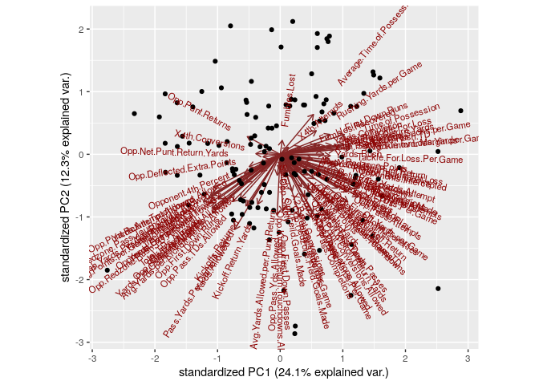

```r
#library(devtools)
#install_github("vqv/ggbiplot")

library(ggbiplot)
ggbiplot(CFB.pca)
```

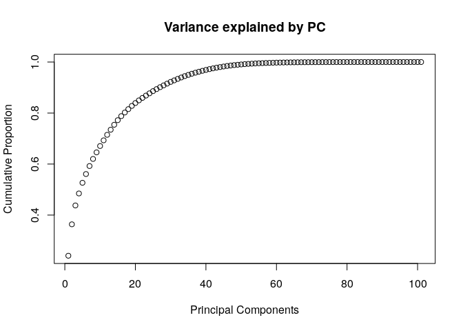

```r
plot(cumsum(CFB.pca$sdev^2/sum(CFB.pca$sdev^2)),
     main = "Variance explained by PC",
     xlab = "Principal Components",
     ylab = "Cumulative Proportion")
```

```r
summary(CFB.pca)$importance[,1:35]
```

```
##                             PC1      PC2      PC3      PC4      PC5
## Standard deviation     4.930688 3.526126 2.733645 2.179389 2.055791
## Proportion of Variance 0.240710 0.123100 0.073990 0.047030 0.041840
## Cumulative Proportion  0.240710 0.363810 0.437800 0.484830 0.526670
##                             PC6      PC7      PC8      PC9     PC10
## Standard deviation     1.860977 1.778635 1.678311 1.613313 1.583481
## Proportion of Variance 0.034290 0.031320 0.027890 0.025770 0.024830
## Cumulative Proportion  0.560960 0.592290 0.620170 0.645940 0.670770
##                            PC11     PC12     PC13    PC14    PC15     PC16
## Standard deviation     1.499748 1.478014 1.419558 1.40415 1.34385 1.269523
## Proportion of Variance 0.022270 0.021630 0.019950 0.01952 0.01788 0.015960
## Cumulative Proportion  0.693040 0.714670 0.734620 0.75414 0.77202 0.787980
##                            PC17     PC18     PC19     PC20     PC21
## Standard deviation     1.196439 1.155966 1.132882 1.064093 1.025485
## Proportion of Variance 0.014170 0.013230 0.012710 0.011210 0.010410
## Cumulative Proportion  0.802150 0.815380 0.828090 0.839300 0.849710
##                            PC22      PC23    PC24      PC25      PC26
## Standard deviation     0.992145 0.9559676 0.94321 0.9340294 0.8908283
## Proportion of Variance 0.009750 0.0090500 0.00881 0.0086400 0.0078600
## Cumulative Proportion  0.859460 0.8685100 0.87732 0.8859500 0.8938100
##                             PC27      PC28      PC29      PC30      PC31
## Standard deviation     0.8774958 0.8464696 0.8312175 0.8250754 0.7769062
## Proportion of Variance 0.0076200 0.0070900 0.0068400 0.0067400 0.0059800
## Cumulative Proportion  0.9014300 0.9085300 0.9153700 0.9221100 0.9280900
##                           PC32      PC33      PC34      PC35
## Standard deviation     0.76369 0.7489658 0.7369578 0.6937465
## Proportion of Variance 0.00577 0.0055500 0.0053800 0.0047700
## Cumulative Proportion  0.93386 0.9394100 0.9447900 0.9495600
```

As we can see above, 35 principal components can explain about 95% of the total variation. So, I decided to include those 35 components into my initial model.

# Binomial Regression

Suppose the response variable $Y_{i}$ for $i = 1,...,n$ is binomially distributed $Bin(m_{i}, p_{i})$ so that:

$P(Y_{i} = y_{i}) = \binom{m_{i}}{y_{i}}p_{i}^{y_{i}}(1-p_{i})^{m_{i}-y_{i}}$

We further assume that the $Y_{i}$ are independent. The individual outcomes or *trials* that compose the response $Y_{i}$ are all subject to the same *q* predictors $(x_{i1},...,x_{iq})$.

In this study, each of the observation is representing winning records of each team. So, we can consider *win* as *‘success’* and *loss* as *‘failure’* in binomial distribution.

Then, we can construct a *linear predictor*:

$\eta_{i} = \beta_{0} + \beta_{1}x_{i1} + ... + \beta_{q}x_{iq}$

We can use a logistic link function $\eta_{i} = log(p_{i}/(1-p_{i}))$

The log-likelihood is then given by:

$l(\beta) = \sum_{i = 1}^{n} [y_{i}\eta_{i} - m_{i}log(1+e_{i}^\eta) + log\binom{m_{i}}{y_{i}}]$

```r
CFB.data$Win.Loss = as.character(CFB.data$Win.Loss)
Win = gsub("-[1-9]?[0-9]", "", CFB.data$Win.Loss)
Win = as.numeric(Win)
Loss = gsub("[1-9]?[0-9]-", "", CFB.data$Win.Loss)
Loss = as.numeric(Loss)
```

```r
CFB = as.data.frame(predict(CFB.pca, CFB.ind), stringsAsFactors = FALSE)
CFB$Win = Win
CFB$Loss = Loss

ncomp = 35

# here we will only model with the first ncomp principal components
varexpr = paste(paste("PC", 1:ncomp, sep=''), collapse='+')
fmla = paste("cbind(Win, Loss) ~", varexpr)

model = glm(fmla, family = binomial, data=CFB)
```

Using stepwise variable selection, we can retain only the necessary predictors in the model.

```r
final.model = step(model, trace = FALSE)
```

```r
final.model
```

```
##
## Call:  glm(formula = cbind(Win, Loss) ~ PC1 + PC3 + PC10, family = binomial,
##     data = CFB)
##
## Coefficients:
## (Intercept)          PC1          PC3         PC10
##     0.11389      0.19797      0.02996     -0.06404
##
## Degrees of Freedom: 129 Total (i.e. Null);  126 Residual
## Null Deviance:       348.4
## Residual Deviance: 51.54     AIC: 420.3
```

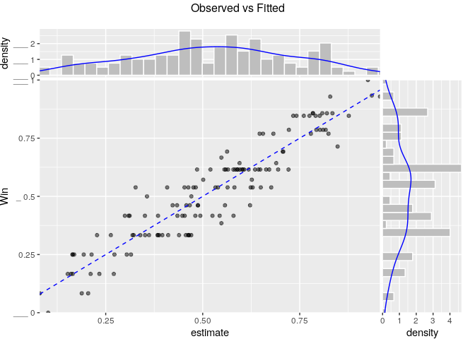

```r
CFB$estimate = fitted(final.model)
CFB$Win = CFB$Win/(CFB$Win + CFB$Loss)

ScatterHist(CFB,'estimate','Win','Observed vs Fitted',
            smoothmethod='identity')
```

The model fits data pretty well!

Project files: https://github.com/aleedk1123/CFB